# mineMS2: Annotation of spectral libraries with exact fragmentation patterns

Alexis Delabrière, Coline Gianfrotta and Etienne Thévenot

2025-06-19

#### Package

mineMS2 1.0.0

# 1 Introduction

mineMS2 is an innovative *de novo* strategy for **searching** **frequent patterns** within a **collection of MS/MS spectra** to help **finding and interpreting structural similarities** between subsets of spectra (Delabrière et al. 2025). Each **pattern is a graph** with **ion peaks as nodes** and **m/z differences as edges**. These m/z differences can be **any difference between the m/z values of two peaks of a spectrum**, provided that they are **frequent** (i.e. detected in at least two spectra). They therefore include **not only neutral losses but also m/z differences between ions that belong to distinct fragmentation paths** of the precursor, which may also prove specific to the fragmentation of specific molecules. The candidate **molecular formulas for each m/z difference** are computed to help interpretation (below 200 Da).

Importantly, this method is **independent of external spectral databases and knowledge of the molecular formula of precursor ions**, to facilitate the characterization of unknown compounds. mineMS2 patterns are **complementary to those of MS2LDA** (van der Hooft et al. 2016), the latter consisting of a list of neutral fragments and losses and being obtained using a probabilistic approach. In particular, the **structure of mineMS2 patterns in the form of exact graphs** (all m/z differences of the pattern are present in all spectra containing this pattern) **facilitates their chemical interpretation**.

This vignette describes the features of the mineMS2 package to **generate and explore fragmentation patterns in a collection from MS/MS spectra**. The companion vignette (*mineMS2_coupling-to-gnps*) further presents the **coupling of mineMS2 with GNPS** (Watrous et al. 2012) to focus on patterns that best explain components of the molecular network.

## 1.1 Data set

The dataset used in both vignettes contains 51 MS/MS spectra from secondary metabolites of *Penicillium nordicum* (one spectrum per compound) acquired on an HPLC system (Luna C18 column; Phenomenex) coupled to an LTQ Orbitrap XL hybrid (Thermo Fisher Scientific) operated in the positive ionization mode at a HCD20 collision energy and a resolution of 7,500 (Hautbergue et al. 2019).

## 1.2 Installation

The package mineMS2 is available at the **GitHub repository** from the [Odiscé](https://github.com/odisce) team:

```r
if (!require(devtools)) install.packages(devtools)
if (!require(mineMS2)) install_github("odisce/mineMS2")
library(mineMS2)
```

# 2 Loading the collection of MS/MS spectra (`ms2Lib`)

The **`ms2Lib`** class is used throughout the workflow to **store the spectra data and metadata, the m/z differences, the fragmentation graphs, and the patterns**.

The `ms2Lib` constructor function takes the **collection of MS/MS spectra as input** either:

- as the name of a single *mgf* file containing all spectra
- as a vector of the individual *mgf* file names
- as the name of the directory containing the individual spectra stored as *mgf* files
- as a list of [Spectrum2](https://rdrr.io/bioc/MSnbase/man/Spectrum2-class.html) objects (from the *MSnbase* package).

**Supplementary metadata** about the spectra (such as the molecule names, or their elemental formulas) can also be provided as a *tsv* tabular file. These metadata are not used in the computations (m/z differences, fragmentation graphs, frequent patterns) but can be displayed in the plot titles (see below). The *tsv* file of metadata should contain as many rows as spectra. By default, spectra are associated to rows in the same order, but if the dataset consists of individual spectrum files, it is possible to match each spectrum to a specific row by using a column *file*.

```r
# Finding the spectra data
pnordicum_mgf.c <- system.file("dataset/pnordicum_ms2_spectra.mgf",
                               package = "mineMS2")

# Supplementary information
pnordicum_metadata.c <- system.file("dataset/pnordicum_ms2_info.tsv",
                                    package = "mineMS2")
pnordicum_metadata.df <- read.table(pnordicum_metadata.c,
                                    header = TRUE,
                                    sep = "\t")
head(pnordicum_metadata.df)
```

```
##   id       mz    rt group polarity id_file         name  formula corrected_rt
## 1  1 481.2905 43.82     B      pos       1                              43.82
## 2  2 481.2905 44.16     B      pos       1                              44.22
## 3  3 147.0640  3.12     B      pos       3  Verrucolone  C6H10O4         3.12
## 4  4 213.1119 15.65     B      pos       3         PC-2 C11H16O4        15.75
## 5  5 215.1276 13.91     B      pos       3 LL-P880alpha C11H18O4        13.94
## 6  6 231.1227  5.66     B      pos       3 LL-P880 beta C11H18O5         5.66
##   fungisporins
## 1
## 2
## 3
## 4
## 5
## 6
```

```r
# Spectra data and metadata are loaded
pnordicum.m2l <- ms2Lib(pnordicum_mgf.c, suppInfos = pnordicum_metadata.df)
```

```
## Reading MGF file C:/Users/et207099/AppData/Local/R/win-library/4.3/mineMS2/dataset/pnordicum_ms2_spectra.mgf.
```

```r
pnordicum.m2l
```

```
## An ms2Lib object containing 51 spectra.
## The available spectral metadata are: mz.precursor file title id mz rt group polarity id_file name formula corrected_rt fungisporins N
## It contains: 0 patterns
```

Note that the two columns *mz.precursor* and *file* have been inserted at the beginning of the metadata table stored in the `ms2Lib` object with the information borrowed from the *mgf* file. In addition, if the *formula* column exists in the initial metadata file, white spaces and special characters are omitted in the metadata table of the `ms2Lib` object and `NA` are inserted when specific formulas are missing (when no formula is provided in the initial metadata, a *formula* column full of `NA` is created in the metadata table of the `ms2Lib` object). Note that **this formula information is not used by the *mineMS2* algorithms** (for display only) to enable *de novo* characterization of unknown compounds.

The metadata can be get back from the `ms2Lib` object with `getInfo`:

```r
ms2lib_metadata.df <- getInfo(pnordicum.m2l, "S")
head(ms2lib_metadata.df)
```

```
##    mz.precursor
## S1     481.2905
## S2     481.2905
## S3     147.0649
## S4     213.1120
## S5     215.1277
## S6     231.1226
##                                                                                           file
## S1 C:/Users/et207099/AppData/Local/R/win-library/4.3/mineMS2/dataset/pnordicum_ms2_spectra.mgf
## S2 C:/Users/et207099/AppData/Local/R/win-library/4.3/mineMS2/dataset/pnordicum_ms2_spectra.mgf
## S3 C:/Users/et207099/AppData/Local/R/win-library/4.3/mineMS2/dataset/pnordicum_ms2_spectra.mgf
## S4 C:/Users/et207099/AppData/Local/R/win-library/4.3/mineMS2/dataset/pnordicum_ms2_spectra.mgf
## S5 C:/Users/et207099/AppData/Local/R/win-library/4.3/mineMS2/dataset/pnordicum_ms2_spectra.mgf
## S6 C:/Users/et207099/AppData/Local/R/win-library/4.3/mineMS2/dataset/pnordicum_ms2_spectra.mgf
##    id       mz    rt group polarity id_file         name  formula corrected_rt
## S1  1 481.2905 43.82     B      pos       1                  <NA>        43.82
## S2  2 481.2905 44.16     B      pos       1                  <NA>        44.22
## S3  3 147.0640  3.12     B      pos       3  Verrucolone  C6H10O4         3.12
## S4  4 213.1119 15.65     B      pos       3         PC-2 C11H16O4        15.75
## S5  5 215.1276 13.91     B      pos       3 LL-P880alpha C11H18O4        13.94
## S6  6 231.1227  5.66     B      pos       3 LL-P880 beta C11H18O5         5.66
##    fungisporins N
## S1              1
## S2              2
## S3              3
## S4              4
## S5              5
## S6              6
```

These metadata (e.g. m/z and retention time) can be linked to the IDs of the spectra as follows (for display in the plots):

```r
pnordicum_ids.c <- paste(paste("mz",ms2lib_metadata.df[,"mz"]),
                         paste("rt",ms2lib_metadata.df[,"rt"]), sep = "_")
pnordicum.m2l <- setIds(pnordicum.m2l, pnordicum_ids.c)
```

## 2.1 Visualizing the spectra

Each spectrum can be displayed with the **`plot`** method by using its ID:

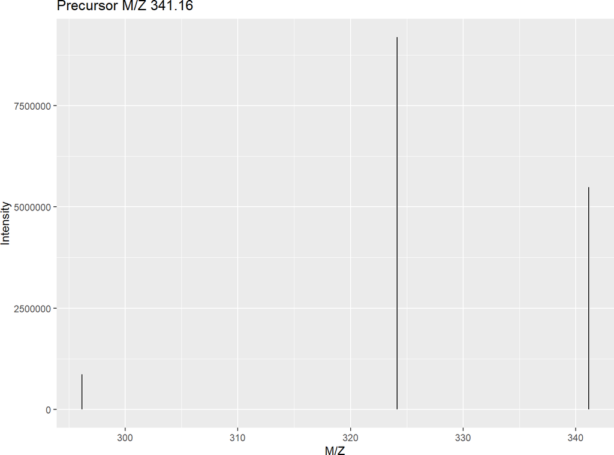

```r
plot(pnordicum.m2l, "S14")
```

Here the S14 index refers to the 14th spectrum of the collection (from aurantiomide C; precursor m/z 341.1605 and retention time 20.09).

```r
getInfo(pnordicum.m2l, "S14")[, c("name", "mz", "corrected_rt")]
```

```
##               name       mz corrected_rt
## S14 Aurantiomide C 341.1605        20.09
```

Note: the list of spectra (as individual `Spectrum2` objects) can be accessed with the `mm2Spectra` method:

```r
ms2_spectra.ls <- mm2Spectra(pnordicum.m2l)
ms2_spectrum.ms2 <- ms2_spectra.ls[[14]]
library(MSnbase) # to use the mz and intensity methods below on the Spectrum2 object
mz(ms2_spectrum.ms2)
```

```
## [1] 296.1385 324.1335 341.1601
```

```r
intensity(ms2_spectrum.ms2)
```

```
## [1]  868762.2 9187019.0 5480650.0
```

# 3 Computing the fragmentation graphs (`discretizeMzDifferences`)

## 3.1 m/z differences

The first step of the *mineMS2* algorithm, **`discretizeMzDifferences`**, **computes the m/z differences** between the peaks in each spectrum and **discretizes (or aligns) them for the whole spectra collection** (so that common m/z differences between spectra have the same value throughout the collection). Note that these m/z differences include not only the neutral losses but also differences between ions that belong to distinct fragmentation paths of the precursor.

This step is very important, as it determines the initial set of fragmentation graphs. The main parameters are listed below:

- `ppm`: The accuracy of the mass spectrometer in *ppm* used to determine the bandwidth of the kernel density estimation (default: `15`)
- `dmz`: The minimum deviation used for bandwidth (in Da; default: `0.007`)
- `count`: The minimum number of spectra in which a m/z difference needs to be present to be considered as frequent (default: `2`)
- `precPpm`: The ppm tolerance used to match the precursor (default: `20`). The `precPpm` and `precDmz` arguments are used to find a peak corresponding to the precursor on the MS/MS spectra. If it is not present, an artificial peak is added
- `precDmz`: The minimum tolerance in Da used to match the precursor (default: `0.02`)
- `maxFrags`: only the `maxFrags` most intense peaks will be considered to build the graph (should be at most 20 to be done in reasonable time; default: `15`)
- `atoms`: list of possible atoms for formula generation, along with their respective maximum number (default: `list("C"=max(limMzFormula)%/%12,"H"=50,"N"=10,"O"=15,"Cl"=2,"S"=2,"P"=2)`)
- `heteroAtoms`: Indicates whether hetero atoms (P,S,Cl) should be used when generating formula for m/z differences (default: `TRUE`)
- `limMzFormula`: the range of m/z difference values for which formulas will be searched (default: `c(14.5, 200)`).
  - For each m/z difference in the range defined by `limMzFormula`, possible formulas are generated, using a decomposition of possible atoms given by the argument `atoms`. If no formula is found, the m/z difference is discarded
  - For m/z differences higher than the `limMzFormula` upper limit, no formula is generated but the m/z difference is kept

We use the default value of the parameters to process the `pnordicum.m2l` spectral collection:

```r
pnordicum.m2l <- discretizeMzDifferences(pnordicum.m2l,
                                         ppm = 15,
                                         dmz = 0.007,
                                         count = 2,
                                         precPpm = 20,
                                         precDmz = 0.02,
                                         maxFrags = 15,
                                         heteroAtoms = TRUE,
                                         limMzFormula = c(14.5, 200))
```

```
## Time difference of 9.282348 secs
## Time difference of 0.01107001 secs
## Time difference of 1.943017 secs
## Time difference of 4.368738 secs
```

After this step, the list of discretized m/z differences labels may be extracted:

```r
head(mzDiffTable(pnordicum.m2l))
```

```
##   lab       mz    mzmin    mzmax count formula
## 1   1 16.02890 16.02424 16.03357    22     CH4
## 2   2 17.02649 17.02182 17.03115    20     H3N
## 3   3 18.01053 18.00586 18.01520    84     H2O
## 4   4 23.99999 23.99532 24.00466    11      C2
## 5   5 26.01568 26.01102 26.02035     6    C2H2
## 6   6 28.03133 28.02667 28.03600    13    C2H4
```

Each row of this table corresponds to one discretized m/z difference, with:

- *mz*: mean value among the occurrences in the spectra collection
- *mzmin*: minimum value
- *mzmax*: maximum value
- *count*: number of occurrences
- *formula*: the possible formula(s), if calculated

The information about a specific m/z difference can be directly accessed with:

```r
getInfo(pnordicum.m2l, "L187")
```

```
##      lab      mz    mzmin    mzmax count
## L187 187 147.068 147.0633 147.0726    41
##                                                                                                                                               formula
## L187 C4H9O3N3|C2H14O4NP|C3H10N5P|CH13O3N3S|C9H9ON|CH15ON3P2|HO7Cl|C6H13ONS|C5H9O4N|C6H5N5|C4H10ON3P|H14N5SP|C3H17ONS2|H5ON9|C3H9O2N5|H9O6N3|C2H13O4NS
```

## 3.2 Fragmentation graphs

The step of discretization also builds the **fragmentation graph** for each spectrum, i.e. the directed acyclic graph (DAG) with the **spectrum peaks as nodes and the frequent (discretized) m/z differences as edges**. Each fragmentation graph can be plotted with the `plot` method in a static or dynamic way (`tkplot` argument set to `FALSE` or `TRUE`, respectively; default: `FALSE`).

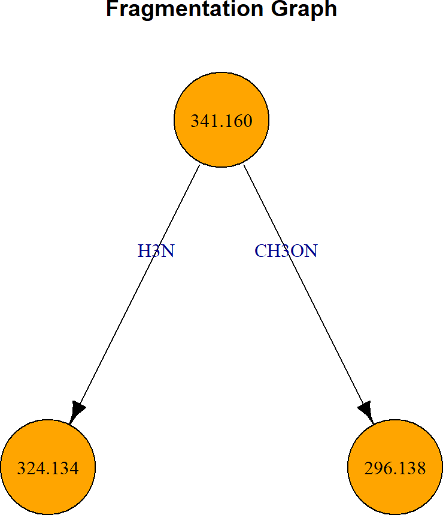

```r
plot(pnordicum.m2l, "D14")
```

Here, the graph D14 corresponds to the spectrum S14.

# 4 Mining frequent fragmentation patterns (`mineClosedSubgraphs`)

The next step consists in **extracting the frequent subgraphs (i.e. the patterns) among the fragmentation graphs**. The **`mineClosedSubgraphs`** method has two main parameters:

- `count`: minimum number of spectra in which a pattern is detected to be considered; should be at least 2 (default: `2`)
- `sizeMin`: minimum size of the pattern (default: `1`)

Note that when the number of frequent m/z differences is high (above 600) and a `sizeMin` value of 1 has been selected, the value will be automatically increased to 2 to avoid computational overload (a warning is displayed)

Here we use the default parameters:

```r
pnordicum.m2l <- mineClosedSubgraphs(pnordicum.m2l, count = 2, sizeMin = 1)
```

```
## Processing completed: 290 patterns mined.
```

The total number of extracted patterns is:

```r
length(mm2Patterns(pnordicum.m2l))
```

```
## [1] 290
```

# 5 Exploring the patterns

Spectra (**S**), m/z differences (**L**), fragmentation graphs (**D**), and patterns (**P**) are stored in the `ms2Lib` object with an ID starting with the corresponding upper case letter and followed by an integer index (e.g. S14, D14, L187). The `findMz` and `select` methods are designed to extract spectra, m/z differences, and patterns of interest. The `plotPatterns` methods can then be used to the patterns and associated spectra.

## 5.1 Getting spectra or m/z differences close to a specific (precursor) m/z (`findMz`)

`findMz` gets the IDs of spectra or m/z differences whose m/z (of the precursor ion in the case of spectra) is close to a specific value; it returns the character vector of corresponding IDs (starting with a S or an L, respectively).

- Use case 1: Looking for spectra with precursor m/z value close to 147.0:

```r
verrucolone_spectra.vc <- findMz(pnordicum.m2l, 147.0, type = "S", ppm = 8, dmz = 0.2)
getInfo(pnordicum.m2l, verrucolone_spectra.vc)
```

```
##    mz.precursor
## S3     147.0649
##                                                                                           file
## S3 C:/Users/et207099/AppData/Local/R/win-library/4.3/mineMS2/dataset/pnordicum_ms2_spectra.mgf
##    id      mz   rt group polarity id_file        name formula corrected_rt
## S3  3 147.064 3.12     B      pos       3 Verrucolone C6H10O4         3.12
##    fungisporins N
## S3              3
```

- Use case 2: Finding an m/z difference corresponding to phenylalanine:

```r
phe_loss.c <- findMz(pnordicum.m2l, type = "L", 147.05, dmz = 0.1)
getInfo(pnordicum.m2l, phe_loss.c)
```

```
##      lab      mz    mzmin    mzmax count
## L187 187 147.068 147.0633 147.0726    41
##                                                                                                                                               formula
## L187 C4H9O3N3|C2H14O4NP|C3H10N5P|CH13O3N3S|C9H9ON|CH15ON3P2|HO7Cl|C6H13ONS|C5H9O4N|C6H5N5|C4H10ON3P|H14N5SP|C3H17ONS2|H5ON9|C3H9O2N5|H9O6N3|C2H13O4NS
```

## 5.2 Getting patterns contained in specific spectra or including specific m/z differences (`select`)

Based on the spectra (or m/z difference) indices selected above, the `select` method enable to retrieve the patterns that are included in all these spectra (or that contain the m/z differences); it returns a list of pattern indices for the query spectra (or m/z differences).

- Use case 1: Patterns in the Verrucolone spectrum:

```r
verrucolone_pattern.ls <- select(pnordicum.m2l, verrucolone_spectra.vc, "P")
verrucolone_pattern.ls
```

```
## $S3
##  [1] "P2"   "P3"   "P4"   "P5"   "P6"   "P7"   "P8"   "P9"   "P13"  "P14"
## [11] "P15"  "P19"  "P20"  "P21"  "P23"  "P30"  "P32"  "P33"  "P41"  "P42"
## [21] "P61"  "P64"  "P65"  "P79"  "P83"  "P84"  "P90"  "P94"  "P95"  "P97"
## [31] "P98"  "P105" "P112" "P113" "P114" "P115" "P116" "P117" "P119" "P120"
## [41] "P121" "P122" "P126" "P127" "P136" "P138" "P146" "P149" "P155"
```

- Use case 2: Patterns including the loss of phenylalanine:

```r
phe_patterns.ls <- select(pnordicum.m2l, phe_loss.c, "P")
phe_patterns.ls
```

```
## $L187
##  [1] "P70"  "P99"  "P100" "P110" "P111" "P142" "P156" "P157" "P159" "P163"
## [11] "P164" "P167" "P172" "P174" "P176" "P183" "P190" "P194" "P195" "P196"
## [21] "P198" "P199" "P202" "P204" "P217" "P218" "P219" "P220" "P221" "P222"
## [31] "P223" "P233" "P234" "P235" "P237" "P240" "P264" "P265" "P266" "P267"
## [41] "P280"
```

Note that the spectra including the loss of phenylalanine can be retrieved the same way:

```r
phe_spectra.ls <- select(pnordicum.m2l, phe_loss.c, "S")
phe_spectra.ls
```

```
## $L187
##  [1] "S17" "S18" "S21" "S22" "S24" "S25" "S26" "S27" "S28" "S29" "S31" "S33"
## [13] "S34" "S36" "S37" "S42" "S51"
```

## 5.3 Visualizing the patterns (`plotPatterns`)

The `plotPatterns` method applied to a character vector of pattern indices displays for each pattern:

- the graph of the pattern; the nodes of this graph are labeled with the sum of m/z differences from the root of the graph, along with the corresponding formula. The edges of the graph are labeled with the corresponding m/z differences, along with the formula. A formula in brackets indicates that several formulas are possible and the one with the closest mass is shown.
- the spectra containing the pattern with colored peaks corresponding to nodes of the pattern
- a list of supplementary information about these spectra

```
##
##
## |    | mz.precursor| id|       mz|    rt|group |polarity | id_file|name                          |formula     | corrected_rt|fungisporins |  N|
## |:---|------------:|--:|--------:|-----:|:-----|:--------|-------:|:-----------------------------|:-----------|------------:|:------------|--:|
## |S17 |     370.1283| 17| 370.1283| 26.51|B     |pos      |       3|Ochratoxin B                  |C20H19NO6   |        26.51|             | 17|
## |S18 |     404.0894| 18| 404.0891| 33.16|B     |pos      |       3|Ochratoxin A                  |C20H18NO6Cl |        33.16|             | 18|
## |S21 |     511.2906| 21| 511.2906| 17.90|B     |pos      |       4|Hydrolyzed fungisporin A      |C28H38N405  |        17.90|known        | 21|
## |S22 |     511.2906| 22| 511.2906| 18.57|B     |pos      |       4|Hydrolyzed Cyclo(VFVF)        |C28H38N4O5  |        18.57|known        | 22|
## |S27 |     525.3060| 27| 525.3060| 20.92|B     |pos      |       4|                              |NA          |        20.92|             | 27|
## |S28 |     527.2853| 28| 527.2853| 12.75|B     |pos      |       4|Hydrolyzed fungisporin B      |C28H38N4O6  |        12.75|known        | 28|
## |S36 |     550.3015| 36| 550.3015| 17.09|B     |pos      |       4|Hydrolyzed Fungisporin D VFWV |C30H39N5O5  |        17.09|known        | 36|
```

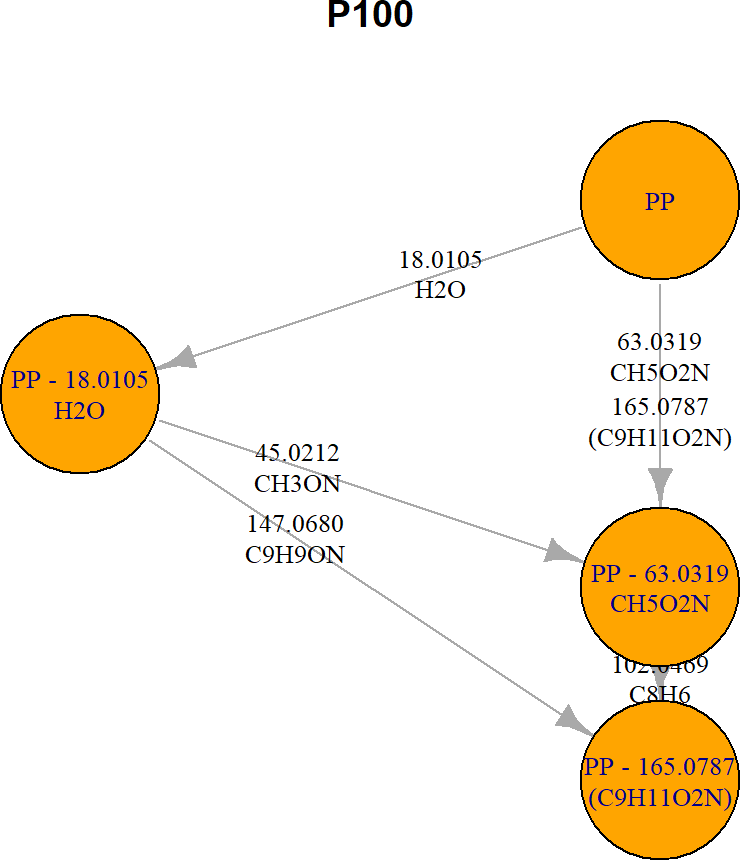

```
##
##
## |    | Mz_diff_mean| Mz_diff_min| Mz_diff_max|Formula                                                                                                                                          |Chosen_formula |
## |:---|------------:|-----------:|-----------:|:------------------------------------------------------------------------------------------------------------------------------------------------|:--------------|
## |3   |      18.0105|     18.0059|     18.0152|H2O                                                                                                                                              |H2O            |
## |24  |      45.0212|     45.0166|     45.0259|CH3ON                                                                                                                                            |CH3ON          |
## |59  |      63.0319|     63.0272|     63.0366|CH5O2N                                                                                                                                           |CH5O2N         |
## |131 |     102.0469|    102.0423|    102.0516|C3H6O2N2,CH11O3P,H10O2N2S,C8H6,C5H10S,C2H6ON4                                                                                                    |C8H6           |
## |187 |     147.0680|    147.0633|    147.0726|H9O6N3,C5H9O4N,C6H5N5,C4H10ON3P,C2H13O4NS,H5ON9,C4H9O3N3,C2H14O4NP,C3H10N5P,CH13O3N3S,C9H9ON,CH15ON3P2,HO7Cl,H14N5SP,C6H13ONS,C3H17ONS2,C3H9O2N5 |C9H9ON         |
## |202 |     165.0787|    165.0740|    165.0833|C4H11O4N3,C5H7N7,C2H16O5NP,C3H12ON5P,CH15O4N3S,C9H11O2N,CH17O2N3P2,H3O8Cl,C2H11N7S,C6H15O2NS                                                     |C9H11O2N       |
```

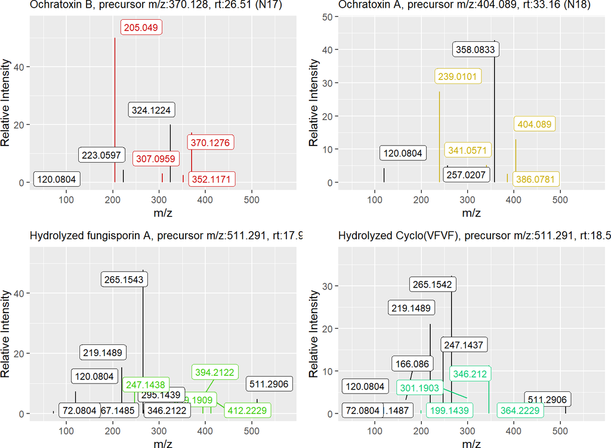

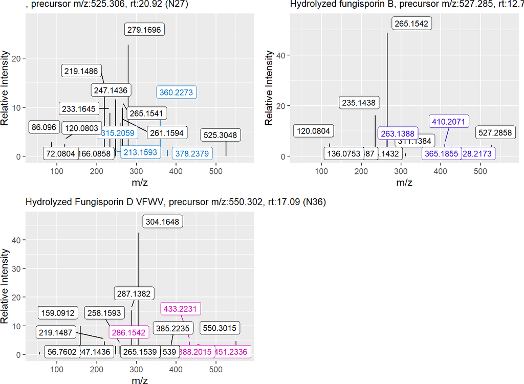

```r
phe_pattern.c <- phe_patterns.ls[[phe_loss.c]][3]
plotPatterns(pnordicum.m2l, phe_pattern.c)
```

These results can be exported in pdf (one pdf file per pattern) by setting the `save_dir` argument to the path of the target directory for saving (default to `"none"` for no export).

```r
dir.create("phe_patterns")
plotPatterns(pnordicum.m2l, phe_pattern.c, save_dir = "phe_patterns")
```